# Lab #4 (part 2) - Logistic and Softmax Regression

This lab will cover logistic regression and softmax regression. It will also touch on a few built-in optimization options, and provide a demonstration of stochastic gradient descent.

As usual, we'll begin by loading familiar libraries:

```python
import pandas as pd
import numpy as np
import matplotlib.pyplot as plt
import sklearn
import math
import scipy
```

Our several examples will use the MNIST handwritten digit dataset (introduced in Lab 2-B):

```python
### Read flattened, processed MNIST data
mnist = pd.read_csv("https://remiller1450.github.io/data/mnist_small.csv")

## Train-test split
from sklearn.model_selection import train_test_split
train, test = train_test_split(mnist, test_size=0.2, random_state=5)

### Separate the label column (outcome)
train_y = train['label']
train_X = train.drop(['label'], axis="columns")

### Create a binary label for 8's
train_y_binary = (train_y == 8).astype(int)
```

### Part 1 - Logistic Regression

The `sklearn` implementation of logistic regression operates similarly to `LinearRegression` with a few noteworthy differences. The code below sets up a pipeline and attempts to fit an ordinary logistic regression model to the training data:

```python
from sklearn.linear_model import LogisticRegression
from sklearn.pipeline import Pipeline

pipe = Pipeline([
('model', LogisticRegression(penalty='none'))
])

log_mod = pipe.fit(train_X, train_y_binary)
```

The code below implements both strategies using `MinMaxScaler()` and the "newton-cg" algorithm, a method that calculates the entire [hessian matrix](https://en.wikipedia.org/wiki/Hessian_matrix) of second order partial derivatives rather than approximating the matrix (as done by "lbfgs").

```python
from sklearn.preprocessing import MinMaxScaler

## Try a different solver w/ scaling
pipe = Pipeline([
('scaler', MinMaxScaler()),
('model', LogisticRegression(penalty='none', solver='newton-cg'))
])

log_mod = pipe.fit(train_X, train_y_binary)
log_mod.score(train_X, train_y_binary)
```

```
1.0
```

We're now able to achieve convergence, but the in-sample classification accuracy of 100% suggests extreme overfitting (which is likely why "lbfgs" struggled to converge).

Fortunately, cross-validation allows us to obtain a more reliable estimate of the model's performance on data it wasn't trained on:

```python
from sklearn.model_selection import cross_validate
cv_res = cross_validate(log_mod, train_X, train_y_binary, cv = 5, scoring = 'accuracy')
np.average(cv_res['test_score'])
```

```
0.9227083333333332
```

Like all of the other models we've cover so far, logistic regression has a `.fit` method, so we can still utilize all of the functions from the `model_selection` and `metrics` modules in `sklearn` that were covered in Lab 3-A.

#### Question #1

- Part A) use `cross_val_predict` and `confusion_matrix` to create a cross-validated confusion matrix for the logistic regression model described in the sections above. Then, calculate this model's F1 score "by hand" using this matrix. When calculating your score, consider the outcome representing the digit being 8 as the positive class.
- Part B) use `cross_val_predict` and `RocCurveDisplay` to create a cross-validated ROC curve. Briefly comment on the performance of logistic regression as a classifier in this application using the ROC curve.

### Part 2 - Softmax Regression

To perform *softmax regression*, we simply use `LogisticRegression` with the additional argument `multi_class='multinomial'`

```python
## Modify pipeline to fit softmax regression
pipe = Pipeline([
('scaler', MinMaxScaler()),
('model', LogisticRegression(penalty='none', multi_class='multinomial'))
])

sm_mod = pipe.fit(train_X, train_y)
sm_mod.score(train_X, train_y)
```

```
1.0
```

Like we saw in the previous section, softmax regression overfits the training data and achieves an in-sample classification accuracy of 100%.

However, cross-validation estimates the model's classification accuracy on new data will be substantially lower:

```python
cv_res = cross_validate(log_mod, train_X, train_y, cv = 5, scoring = 'accuracy')
np.average(cv_res['test_score'])
```

```
0.8758333333333332
```

Since softmax regression is used in classification problems with multiple outcome classes, we might consider using alternative performance metrics described in the "Multiple Classes" section of Lab 3-A (Part 5 of the lab).

#### Question #2

- Use pipelines and 5-fold cross-validation to compare the performance of softmax regression with $k$-nearest neighbors using `n_neighbors=20`, distance weighting, and euclidean distance calculations on the MNIST data. Use min-max scaling as a preprocessing step in your pipeline to promote numerical stability. Report a cross-validated F1-score calculated using macro-averaging for each model.

### Part 3 - Weights and predictions

In logistic regression, the prediction scores (ie: $\mathbf{x}_i^T\mathbf{w}$ for the $i^{th}$ observation) are linked to probabilities of the positive class via the *sigmoid function*:

$$log\big(\tfrac{\pi_i}{1-\pi_i}\big) = \mathbf{x}_i^T\mathbf{w}$$

For future calculations, we can denote $\eta_i = \mathbf{x}_i^T\mathbf{w}$ and recognize:

$$\pi_i = g(\eta_i) = \tfrac{1}{1 + exp(-\mathbf{x}_i^T\mathbf{w})}$$

We can verify this relationship by manually calculating prediction scores/probabilities and comparing them with the output returned by `LogisticRegression`:

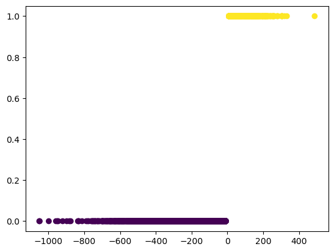

```python
## Refit logistic regression
pipe = Pipeline([
('scaler', MinMaxScaler()),
('model', LogisticRegression(penalty='none', solver='newton-cg'))
])
log_mod = pipe.fit(train_X, train_y_binary)

## Store the weights and bias
w = log_mod.named_steps['model'].coef_
b = log_mod.named_steps['model'].intercept_

## Calculate eta manually using the dot product of X and w + the bias term
train_Xs =  MinMaxScaler().fit_transform(train_X)
eta = np.dot(train_Xs, np.transpose(w)) + b

## Use eta to calculate probabilities of the positive class
pi = 1/(1 + np.exp(-eta))

## Display relationship between eta and pi
plt.scatter(eta, pi, c=train_y_binary.astype('category'))
plt.show()
```

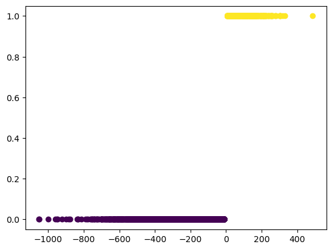

```python
## Now let's extract sklearn's predicted probabilities using `predict_proba`:
pi_m = log_mod.named_steps['model'].predict_proba(train_Xs)
plt.scatter(eta, pi_m[:,1], c=train_y_binary.astype('category'))
plt.show()
```

Comparing the two graphics created above, we can see that our manual calculation of $\eta$ and $\pi$ is correct (since both graphs are identical). However, our results in this example are somewhat atypical.

Normally, we'd expect to see the sigmoid function in this plots. To demonstrate the relationship between $\eta$ and $\pi$ that we'd typically expect, let's quickly re-do this example using the Iowa City Home Sales data:

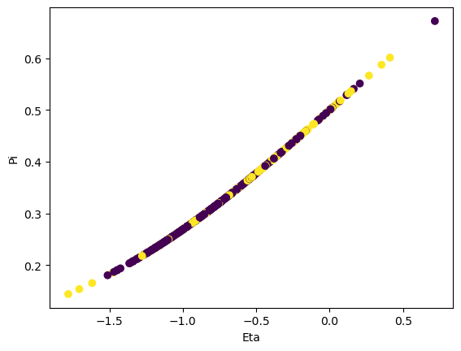

```python
## Load data
ic = pd.read_csv("https://remiller1450.github.io/data/IowaCityHomeSales.csv")
train_ic, test_ic = train_test_split(ic, test_size=0.2, random_state=7)

## Create X and y
train_num = train_ic.select_dtypes("number")
train_ic_y = (train_num['assessed'] > train_num['sale.amount']).astype(int)
train_ic_X = train_num.drop(['assessed','sale.amount'],axis=1)

## Fit logistic regression
pipe = Pipeline([
('scaler', MinMaxScaler()),
('model', LogisticRegression(penalty='none', solver='newton-cg'))
])
ic_log_mod = pipe.fit(train_ic_X, train_ic_y)

## Store the weights and bias
w = ic_log_mod.named_steps['model'].coef_
b = ic_log_mod.named_steps['model'].intercept_

## Calculate eta manually using the dot product of X and w + the bias term
train_Xs =  MinMaxScaler().fit_transform(train_ic_X)
eta = np.dot(train_Xs, np.transpose(w)) + b

## Use eta to calculate probabilities of the positive class
pi = 1/(1 + np.exp(-eta))

## Display
plt.scatter(eta, pi, c=train_ic_y.astype('category'))
plt.xlabel("Eta")
plt.ylabel("Pi")
plt.show()
```

In this new example, we see that higher values of $\eta_i$ (higher scores) correspond with higher predicted probabilities of a home being over-assessed, and this relationship follows a sigmoid curve.

#### Question #3

- Consider the two applications that were explored in Section 3 (MNIST and Iowa City Home Sales) and briefly explain how these graphs relate to the in-sample classification accuracy of each model (when fit to the full training set and evaluated without cross-validation). Recall that in the MNIST example in-sample accuracy was 100%, while the Iowa City Home Sales example it was substantially less than 100%.

## Part 4 - Interpretting Weights

A strength of logistic regression relative to other binary classification models is the ability to interpret and understand each of the estimated weights. By virtue of the model's form, we see:

$$log\big(\tfrac{\pi}{1-\pi}\big) = w_0 + w_1X_1 + \ldots + w_pX_p $$$$\implies \tfrac{\pi}{1-\pi} = exp(w_0 + w_1X_1 + \ldots + w_pX_p)$$$$\implies \tfrac{\pi}{1-\pi} = exp(w_0)*exp(w_1X_1)* \ldots *exp(w_pX_p)$$

The left-hand side of the this equation, $\tfrac{\pi}{1-\pi}$, is the [odds](https://en.wikipedia.org/wiki/Odds) of an observation belonging to the positive class.

- The exponent of the bias, $exp(w_0)$, reflects the baseline odds of the positive class.
- The exponent of $w_p$ reflects the multiplicative effect of a 1-unit change in $X_p$ on the odds of an observation belonging to the positive class.

For example, suppose a predictor's weight is 0.44. We can calculate $e^{0.44} = 1.55$, indicating that a 1-unit change in this predictor corresponds with an estimated 55% increase in the odds of an observation belonging to the positive class.

When interpretting weights, it is important to consider whether you've rescaled the data during the model building process. If you've applied standardization, 1-unit change is actually a 1-standard deviation change in the predictor in terms of its original units. If you've applied min-max scaling, a 1-unit change reflects going from the minimum observed value to the maximum observed value.

#### Question #4

- Using the logistic regression model fit to the Iowa City Home Sales data in Part 3, (ie: `ic_log_mod`), find the estimated weight for the predictor 'bedrooms' and interpret this weight after exponentiation.

### Part 5 - Optimization

Unlike linear regression, neither logistic nor softmax regression have a closed form solution, so weights must be estimated using iterative algorithms. As you've already seen in this lab, there are many different algorithms capable of solving for an optimal set of weights (note that an optimal set does exist, since the *cross entropy cost function* has a single minimum).

In this section of the lab, we'll explore the process of solving for these weights. To begin, we need to define the cost function:

$$Cost = -\tfrac{1}{n}\sum_{i=1}^{n}\big(y_ilog(g(\eta_i)) + (1-y_i)log(1-g(\eta_i))\big)$$

$$Gradient = (g(\eta_i)-y)\mathbf{x}_i$$

Note that $\mathbf{x}_i$ is the row vector corresponding to the single observation we've considering.

We can implement this update scheme by randomly reordering the data, looping through it one-at-atime, and repeating as necessary.

The code below demonstrates *stochastic gradient descent* for the Iowa City Home Sales data. You should reference this code during *Question #5* (which appears at the end of this section).

```python
## First, reload IC data
ic = pd.read_csv("https://remiller1450.github.io/data/IowaCityHomeSales.csv")

## Train-test split
train_ic, test_ic = train_test_split(ic, test_size=0.2, random_state=7)

## Recreate X and Y
train_num = train_ic.select_dtypes("number")
train_ic_y = (train_num['assessed'] > train_num['sale.amount']).astype(int)
train_ic_X = train_num.drop(['assessed','sale.amount'],axis=1)
train_Xs =  MinMaxScaler().fit_transform(train_ic_X)
```

```python
## Define Functions
import random
def cost_function(x, y, w):
    eta = np.dot(x,w)
    pred_y = 1/(1 + np.exp(-eta))
    cost = -y*np.log(pred_y) - (1-y)*np.log(1-pred_y)
    return cost

def grad_descent(X, y, w, alpha, n_iter):
    n = len(y)
    costs = np.zeros(n_iter)

    for i in range(n_iter):
        idx = random.sample(range(n), n)
        temp_cost = 0.0

        for si in range(n):
            random_y = y.iloc[idx[si]]
            random_x = np.append(1,X[idx[si],:])
            eta = np.dot(random_x,w)
            pred_y = 1/(1 + np.exp(-eta))
            err =  (pred_y - random_y).item()
            grad = random_x*err
            w = w - alpha*grad
            temp_cost += cost_function(random_x, random_y, w)

        costs[i] = temp_cost
    return w, costs
```

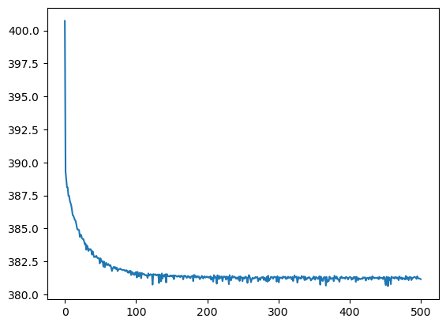

```python
## Plot of results
p = np.shape(train_Xs)[1]+1
n = len(train_ic_y)
nit = 500
gdres = grad_descent(X=train_Xs,y=train_ic_y,w=np.zeros(p),alpha=0.005, n_iter = nit)
plt.plot(np.linspace(0, nit, nit),gdres[1])
plt.show()
```

It's worth knowing that stochastic gradient descent is one of the most widely used algorithms for estimating the weights in neural networks, as the gradient can be computed using chain rule.

#### Question #5

- **Part A**: The cost function uses the command: `np.dot(x, w)`. Briefly explain what this command calculates and what the dimension of the output is.
- **Part B**: Consider an observation belonging to the positive class (ie: $y_i = 1$) with a prediction score of +2.5. What is the cost associated with this observation?
- **Part C**: In the grad_descent function, what is being returned by `random.sample(..)`?
- **Part D**: In the grad_descent function, what is being returned by `np.append(1,X[idx[si],:])`? Why is a '1' included here?
- **Part E**: After the 500 iterations of the grad_descent function, do you expect the final set of weight estimates to be *exactly identical* to those found using `LogisticRegression()`? Briefly explain.